# Ventas Apple

Antonio Romero Mtnez-Eiroa

16/11/2020

### Carga y tratamiento de datos

Cargamos el dataframe con el que vamos a trabajar.

```r
rawData <- read.csv("IngresosApple.csv", sep = ";", dec = ",")

rawData
```

```
##    Trimestre Ingresos
## 1    Q2 2008     7980
## 2    Q3 2008     7561
## 3    Q4 2008    11520
## 4    Q1 2009    11880
## 5    Q2 2009     9084
## 6    Q3 2009     9734
## 7    Q4 2009    12207
## 8    Q1 2010    15683
## 9    Q2 2010    13499
## 10   Q3 2010    15700
## 11   Q4 2010    20343
## 12   Q1 2011    26741
## 13   Q2 2011    24667
## 14   Q3 2011    28571
```

[output cut: 24 more lines]

Lo tansformamos a formato xts y zoo para trabajar con series temporales.

```
##             [,1]
## 2008-04-01  7980
## 2008-07-01  7561
## 2008-10-01 11520
## 2009-01-01 11880
## 2009-04-01  9084
## 2009-07-01  9734
## 2009-10-01 12207
## 2010-01-01 15683
## 2010-04-01 13499
## 2010-07-01 15700
## 2010-10-01 20343
## 2011-01-01 26741
## 2011-04-01 24667
## 2011-07-01 28571
## 2011-10-01 28270
## 2012-01-01 46333
## 2012-04-01 39186
## 2012-07-01 35023
## 2012-10-01 35966
## 2013-01-01 54512
## 2013-04-01 43603
## 2013-07-01 35323
## 2013-10-01 37472
## 2014-01-01 57594
## 2014-04-01 45646
## 2014-07-01 37432
## 2014-10-01 42123
## 2015-01-01 74599
## 2015-04-01 58010
## 2015-07-01 49605
## 2015-10-01 51501
## 2016-01-01 75324
## 2016-04-01 50557
## 2016-07-01 42358
## 2016-10-01 46852
## 2017-01-01 78351
## 2017-04-01 52896
## 2017-07-01 45408
```

```r
xIngresos <- xts(rawData$Ingresos, order.by = rawDate)

xIngresos <- to.quarterly(xIngresos)

xIngresos
```

```
##         xIngresos.Open xIngresos.High xIngresos.Low xIngresos.Close
## 2008 Q2           7980           7980          7980            7980
## 2008 Q3           7561           7561          7561            7561
## 2008 Q4          11520          11520         11520           11520
## 2009 Q1          11880          11880         11880           11880
## 2009 Q2           9084           9084          9084            9084
## 2009 Q3           9734           9734          9734            9734
## 2009 Q4          12207          12207         12207           12207
## 2010 Q1          15683          15683         15683           15683
## 2010 Q2          13499          13499         13499           13499
## 2010 Q3          15700          15700         15700           15700
## 2010 Q4          20343          20343         20343           20343
## 2011 Q1          26741          26741         26741           26741
## 2011 Q2          24667          24667         24667           24667
## 2011 Q3          28571          28571         28571           28571
```

[output cut: 24 more lines]

```r
zIngresos = as.zoo(xIngresos$xIngresos.Close)
```

### Análisis previo

Obeservamos gráficamente la evolución de los ingresos trimestrales de Apple. La gráfica muestra una tendencia claramente positiva y un aumento de la varianza en los años más recientes.

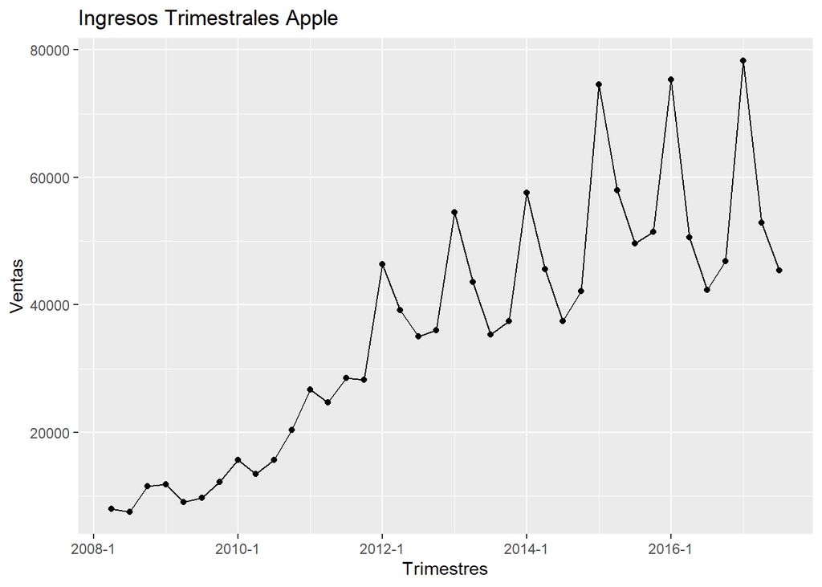

A continuación se muestra también la evolución interanual de los ingresos para cada trimestre. Vemos una tedencia claramente positiva.

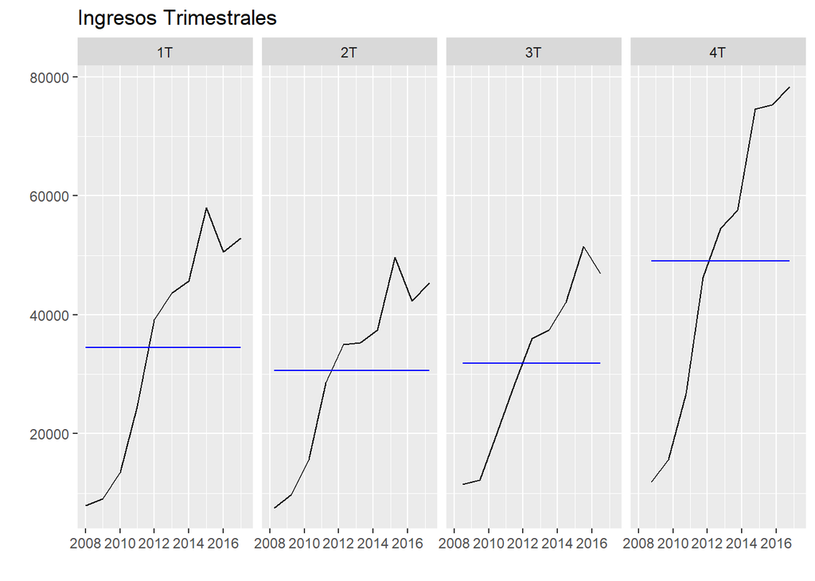

Se analizan las componentes estacional, de tendencia e irregular que afectan a la evolución. Se meustran sus valores y se grafica a continuación.

```
##  Call:
##  stl(x = tsIngresos[, 1], s.window = "periodic")
##
## Components
##          seasonal     trend   remainder
## 2008 Q1 -1191.515 11987.713 -2816.19786
## 2008 Q2 -6202.795 11054.647  2709.14756
## 2008 Q3 -4388.396 10306.954  5601.44193
## 2008 Q4 11782.720  9712.795 -9615.51515
## 2009 Q1 -1191.515 10313.378   -37.86329
## 2009 Q2 -6202.795 11865.051  4071.74373
## 2009 Q3 -4388.396 12348.763  4246.63276
## 2009 Q4 11782.720 12927.130 -9026.85026
## 2010 Q1 -1191.515 14968.422  -277.90712
## 2010 Q2 -6202.795 18282.820  3619.97453
```

[output cut: 28 more lines]

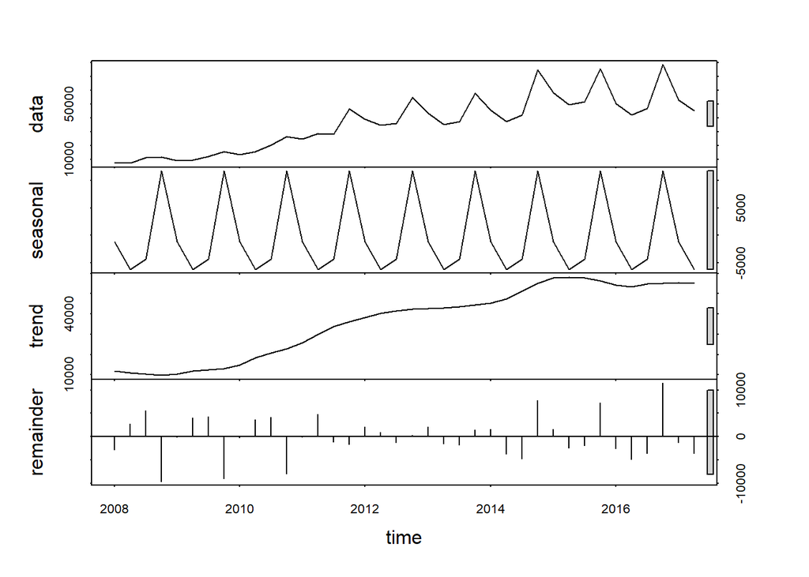